# US Colleges Data Analysis

Usage of ggplot and Linear Regression Model to Answer the following questions:

1. Do colleges with larger full time enrollments have lower graduation rates?
2. Is this different for public and private institutions?
3. If it is different for more selective schools?

**Know the Dataset**

```r
?College
glimpse(College)
```

```
Rows: 777
Columns: 18
$ Private     <fct> Yes, Yes, Yes, Yes, Yes, Yes, Yes, Yes, Yes, Yes, Yes, Yes, Yes, Yes, Yes, Yes, Yes, Yes,…
$ Apps        <dbl> 1660, 2186, 1428, 417, 193, 587, 353, 1899, 1038, 582, 1732, 2652, 1179, 1267, 494, 1420,…
$ Accept      <dbl> 1232, 1924, 1097, 349, 146, 479, 340, 1720, 839, 498, 1425, 1900, 780, 1080, 313, 1093, 9…
$ Enroll      <dbl> 721, 512, 336, 137, 55, 158, 103, 489, 227, 172, 472, 484, 290, 385, 157, 220, 418, 423, …
$ Top10perc   <dbl> 23, 16, 22, 60, 16, 38, 17, 37, 30, 21, 37, 44, 38, 44, 23, 9, 83, 19, 14, 24, 25, 20, 20…
$ Top25perc   <dbl> 52, 29, 50, 89, 44, 62, 45, 68, 63, 44, 75, 77, 64, 73, 46, 22, 96, 40, 23, 54, 44, 63, 5…
$ F.Undergrad <dbl> 2885, 2683, 1036, 510, 249, 678, 416, 1594, 973, 799, 1830, 1707, 1130, 1306, 1317, 1018,…
$ P.Undergrad <dbl> 537, 1227, 99, 63, 869, 41, 230, 32, 306, 78, 110, 44, 638, 28, 1235, 287, 5, 281, 326, 1…
$ Outstate    <dbl> 7440, 12280, 11250, 12960, 7560, 13500, 13290, 13868, 15595, 10468, 16548, 17080, 9690, 1…
$ Room.Board  <dbl> 3300, 6450, 3750, 5450, 4120, 3335, 5720, 4826, 4400, 3380, 5406, 4440, 4785, 4552, 3640,…
$ Books       <dbl> 450, 750, 400, 450, 800, 500, 500, 450, 300, 660, 500, 400, 600, 400, 650, 450, 660, 550,…
$ Personal    <dbl> 2200, 1500, 1165, 875, 1500, 675, 1500, 850, 500, 1800, 600, 600, 1000, 400, 2449, 1400, …
$ PhD         <dbl> 70, 29, 53, 92, 76, 67, 90, 89, 79, 40, 82, 73, 60, 79, 36, 78, 93, 48, 62, 60, 69, 83, 5…
$ Terminal    <dbl> 78, 30, 66, 97, 72, 73, 93, 100, 84, 41, 88, 91, 84, 87, 69, 84, 98, 61, 66, 62, 82, 96, …
$ S.F.Ratio   <dbl> 18.1, 12.2, 12.9, 7.7, 11.9, 9.4, 11.5, 13.7, 11.3, 11.5, 11.3, 9.9, 13.3, 15.3, 11.1, 14…
$ perc.alumni <dbl> 12, 16, 30, 37, 2, 11, 26, 37, 23, 15, 31, 41, 21, 32, 26, 19, 63, 14, 18, 5, 35, 14, 25,…
$ Expend      <dbl> 7041, 10527, 8735, 19016, 10922, 9727, 8861, 11487, 11644, 8991, 10932, 11711, 7940, 9305…
$ Grad.Rate   <dbl> 60, 56, 54, 59, 15, 55, 63, 73, 80, 52, 73, 76, 74, 68, 55, 69, 100, 59, 46, 34, 48, 70, …
```

**Exploratory Graphics to view Data**

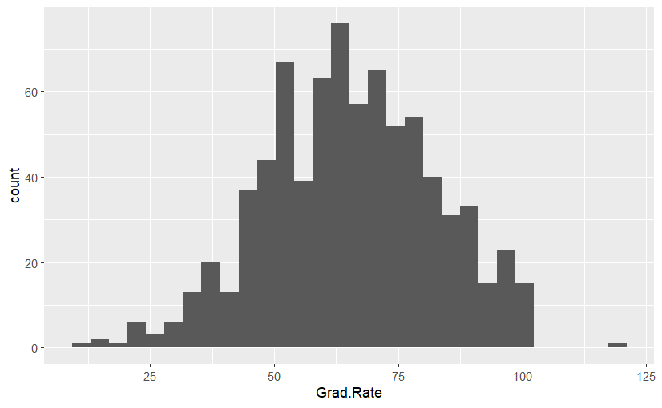

```r
ggplot(College,aes(x=Grad.Rate))+geom_histogram() #Note Outlier
```

Making new filtered data frame to see suspicious college Grad rates

```r
suspicious <- filter(College,Grad.Rate>= 100)
View(suspicious)
```

**Analysis for Question 1**

Do colleges with larger full time enrollments have lower graduation rates?

Plotting a scatter plot between full time UG enrollments and Graduation Rates where the full time enrollments are in base 10

making a sub data frame called **college_sm** where the full time UG enrollments are in base 10 with selected attributes

```r
college_sm <- College %>%
  mutate(log_full=log10(F.Undergrad))%>%
  select(Grad.Rate,
         log_full,
         Private,
         Top25perc)

view(college_sm)
```

Plotting and Creating a model

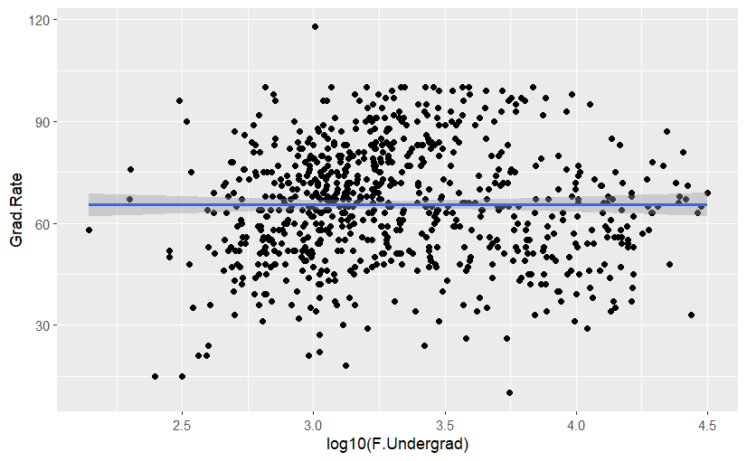

```r
ggplot(College,aes(x=log10(F.Undergrad),y=Grad.Rate))+geom_point()+geom_smooth(method = "lm")
```

```r
model_undergrad <- lm(Grad.Rate ~ log_full,data=college_sm)
summary(model_undergrad)
```

```
Call:
lm(formula = Grad.Rate ~ log_full, data = college_sm)

Residuals:
    Min      1Q  Median      3Q     Max
-55.501 -12.433  -0.434  12.539  52.564

Coefficients:
            Estimate Std. Error t value Pr(>|t|)
(Intercept) 65.17524    4.62722  14.085   <2e-16 ***
log_full     0.08688    1.38301   0.063     0.95
---
Signif. codes:  0 ‘***’ 0.001 ‘**’ 0.01 ‘*’ 0.05 ‘.’ 0.1 ‘ ’ 1

Residual standard error: 17.19 on 775 degrees of freedom
Multiple R-squared:  5.092e-06, Adjusted R-squared:  -0.001285
F-statistic: 0.003946 on 1 and 775 DF,  p-value: 0.9499
```

The High p value and the flat line in the LR plot tells that maybe **full time undergradutes dont have a accurate description of the graduation rates.**

**Analysis For Question 2**

Is this different for public and private institutions?

adding a variable aesthetic of color in the scatter plot that differentiates between public and private institutions and adds a lm line to distinguish the trend

plot and model:

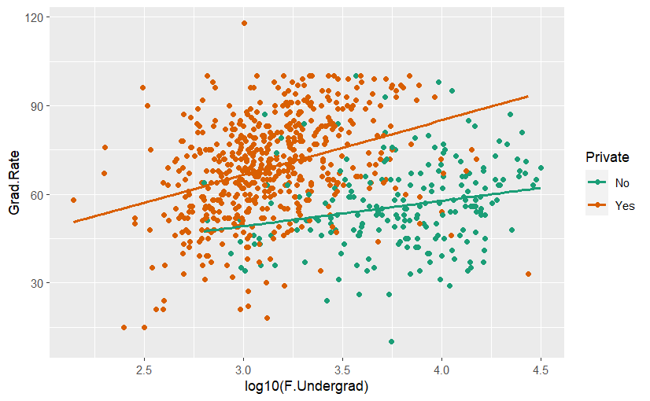

```r
ggplot(College,aes(x=log10(F.Undergrad),y=Grad.Rate,color=Private))+geom_point()+geom_smooth(method = "lm",se=FALSE)+scale_color_brewer(palette = 'Dark2')
```

```r
model_private <- lm(Grad.Rate ~ Private + log_full,data=college_sm)
summary(model_private)
```

```
Call:
lm(formula = Grad.Rate ~ Private + log_full, data = college_sm)

Residuals:
    Min      1Q  Median      3Q     Max
-55.826  -9.581  -0.128  10.752  51.007

Coefficients:
            Estimate Std. Error t value Pr(>|t|)
(Intercept)   -1.784      6.330  -0.282    0.778
PrivateYes    23.007      1.646  13.978   <2e-16 ***
log_full      15.235      1.644   9.266   <2e-16 ***
---
Signif. codes:  0 ‘***’ 0.001 ‘**’ 0.01 ‘*’ 0.05 ‘.’ 0.1 ‘ ’ 1

Residual standard error: 15.37 on 774 degrees of freedom
Multiple R-squared:  0.2016,    Adjusted R-squared:  0.1995
F-statistic:  97.7 on 2 and 774 DF,  p-value: < 2.2e-16
```

the low p value and the plot evidently shows that **a private college sees significantly higher grad rates compared to non-private colleges**

**Analysis For Question 3**

If it is different for more selective schools?

does the top25% of the universities make any difference about the graduation rates.

model and plots for the same:

```r
model_top <- lm(Grad.Rate ~ Private+log_full+Top25perc,data=college_sm)
summary(model_top)
```

```
Call:
lm(formula = Grad.Rate ~ Private + log_full + Top25perc, data = college_sm)

Residuals:
    Min      1Q  Median      3Q     Max
-56.702  -9.314   0.144   9.349  57.401

Coefficients:
            Estimate Std. Error t value Pr(>|t|)
(Intercept) 11.55059    5.91262   1.954   0.0511 .
PrivateYes  16.11989    1.61439   9.985  < 2e-16 ***
log_full     6.99253    1.65593   4.223  2.7e-05 ***
Top25perc    0.34060    0.02819  12.084  < 2e-16 ***
---
Signif. codes:  0 ‘***’ 0.001 ‘**’ 0.01 ‘*’ 0.05 ‘.’ 0.1 ‘ ’ 1

Residual standard error: 14.1 on 773 degrees of freedom
Multiple R-squared:  0.3284,    Adjusted R-squared:  0.3258
F-statistic:   126 on 3 and 773 DF,  p-value: < 2.2e-16
```

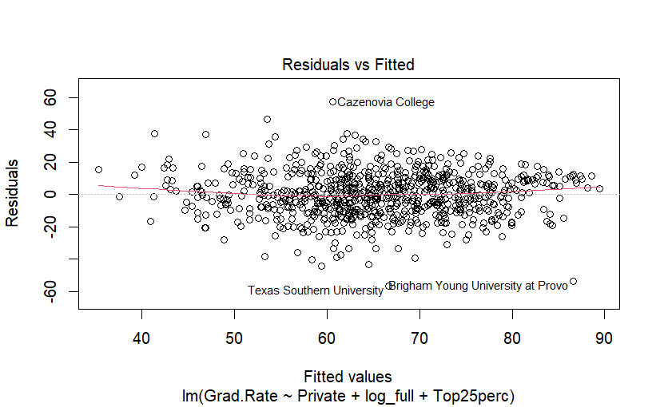

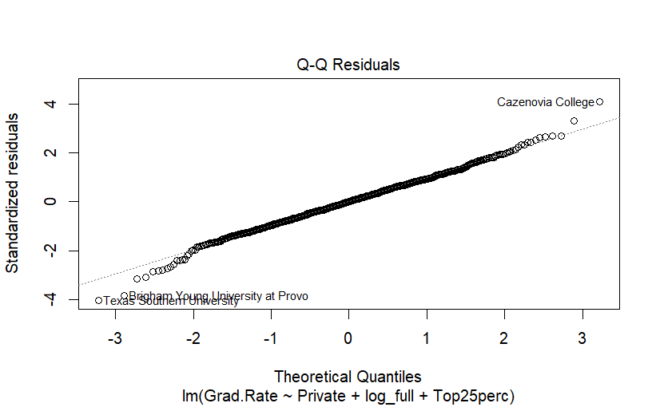

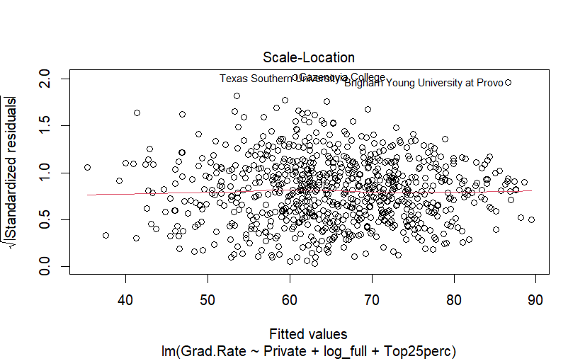

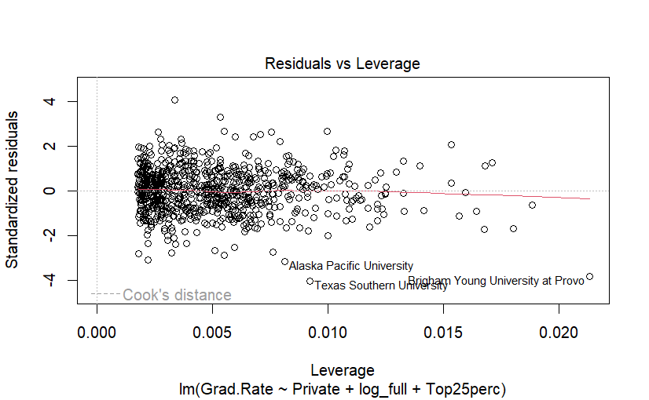

```r
plot(model_top)
```